# Practical Machine Learning Project - Build model for Qualitative Activity Recognition of Weight Lifting Exercises

Arunkumar Maniam rajan

28 September 2017

## Synopsis

In this project we would try to build a model to predict with how much quality an activity is performed. This project uses the data from study [WLE] (http://groupware.les.inf.puc-rio.br/har#weight_lifting_exercises)

## Importing data set.

Training data and test data have been downloaded from [training] (https://d396qusza40orc.cloudfront.net/predmachlearn/pml-training.csv) and [testing] (https://d396qusza40orc.cloudfront.net/predmachlearn/pml-testing.csv)

### Loading the data set and importing packages

This project uses caret for building the model.

```r
library(caret)
training <- read.csv("~/Downloads/pml-training.csv")
testing <- read.csv("~/Downloads/pml-testing.csv")
```

## Checking the nature of data

The best way to start the analysis is to check the nature of the data. Use various tools like summary, structure, nrows etc. The things to look at is 1. Which columns has NA’s 2. Which columns has not valid data. 3. What features the test set contains.

Also checked the experiment to know what each column means. This will help us what covariants or the features to select.

```r
str(training)
str(testing)
```

## Preprocessing

### Near zero values

Check for near 0 columns.

```r
pre_nzv <- nearZeroVar(training,saveMetrics=T)
pre_nzv[pre_nzv$nzv==TRUE,]
```

```
##                          freqRatio percentUnique zeroVar  nzv
## new_window                47.33005    0.01019264   FALSE TRUE
## kurtosis_roll_belt      1921.60000    2.02323922   FALSE TRUE
## kurtosis_picth_belt      600.50000    1.61553358   FALSE TRUE
## kurtosis_yaw_belt         47.33005    0.01019264   FALSE TRUE
## skewness_roll_belt      2135.11111    2.01304658   FALSE TRUE
## skewness_roll_belt.1     600.50000    1.72255631   FALSE TRUE
## skewness_yaw_belt         47.33005    0.01019264   FALSE TRUE
## max_yaw_belt             640.53333    0.34654979   FALSE TRUE
## min_yaw_belt             640.53333    0.34654979   FALSE TRUE
## amplitude_yaw_belt        50.04167    0.02038528   FALSE TRUE
## avg_roll_arm              77.00000    1.68178575   FALSE TRUE
## stddev_roll_arm           77.00000    1.68178575   FALSE TRUE
## var_roll_arm              77.00000    1.68178575   FALSE TRUE
## avg_pitch_arm             77.00000    1.68178575   FALSE TRUE
## stddev_pitch_arm          77.00000    1.68178575   FALSE TRUE
## var_pitch_arm             77.00000    1.68178575   FALSE TRUE
## avg_yaw_arm               77.00000    1.68178575   FALSE TRUE
## stddev_yaw_arm            80.00000    1.66649679   FALSE TRUE
## var_yaw_arm               80.00000    1.66649679   FALSE TRUE
## kurtosis_roll_arm        246.35897    1.68178575   FALSE TRUE
## kurtosis_picth_arm       240.20000    1.67159311   FALSE TRUE
## kurtosis_yaw_arm        1746.90909    2.01304658   FALSE TRUE
## skewness_roll_arm        249.55844    1.68688207   FALSE TRUE
## skewness_pitch_arm       240.20000    1.67159311   FALSE TRUE
## skewness_yaw_arm        1746.90909    2.01304658   FALSE TRUE
## max_roll_arm              25.66667    1.47793293   FALSE TRUE
## min_roll_arm              19.25000    1.41677709   FALSE TRUE
## min_pitch_arm             19.25000    1.47793293   FALSE TRUE
## amplitude_roll_arm        25.66667    1.55947406   FALSE TRUE
## amplitude_pitch_arm       20.00000    1.49831821   FALSE TRUE
## kurtosis_roll_dumbbell  3843.20000    2.02833554   FALSE TRUE
## kurtosis_picth_dumbbell 9608.00000    2.04362450   FALSE TRUE
## kurtosis_yaw_dumbbell     47.33005    0.01019264   FALSE TRUE
## skewness_roll_dumbbell  4804.00000    2.04362450   FALSE TRUE
## skewness_pitch_dumbbell 9608.00000    2.04872082   FALSE TRUE
## skewness_yaw_dumbbell     47.33005    0.01019264   FALSE TRUE
## max_yaw_dumbbell         960.80000    0.37203139   FALSE TRUE
## min_yaw_dumbbell         960.80000    0.37203139   FALSE TRUE
## amplitude_yaw_dumbbell    47.92020    0.01528896   FALSE TRUE
## kurtosis_roll_forearm    228.76190    1.64101519   FALSE TRUE
## kurtosis_picth_forearm   226.07059    1.64611151   FALSE TRUE
## kurtosis_yaw_forearm      47.33005    0.01019264   FALSE TRUE
## skewness_roll_forearm    231.51807    1.64611151   FALSE TRUE
## skewness_pitch_forearm   226.07059    1.62572623   FALSE TRUE
## skewness_yaw_forearm      47.33005    0.01019264   FALSE TRUE
## max_roll_forearm          27.66667    1.38110284   FALSE TRUE
## max_yaw_forearm          228.76190    0.22933442   FALSE TRUE
## min_roll_forearm          27.66667    1.37091020   FALSE TRUE
## min_yaw_forearm          228.76190    0.22933442   FALSE TRUE
## amplitude_roll_forearm    20.75000    1.49322189   FALSE TRUE
## amplitude_yaw_forearm     59.67702    0.01528896   FALSE TRUE
## avg_roll_forearm          27.66667    1.64101519   FALSE TRUE
## stddev_roll_forearm       87.00000    1.63082255   FALSE TRUE
## var_roll_forearm          87.00000    1.63082255   FALSE TRUE
## avg_pitch_forearm         83.00000    1.65120783   FALSE TRUE
## stddev_pitch_forearm      41.50000    1.64611151   FALSE TRUE
## var_pitch_forearm         83.00000    1.65120783   FALSE TRUE
## avg_yaw_forearm           83.00000    1.65120783   FALSE TRUE
## stddev_yaw_forearm        85.00000    1.64101519   FALSE TRUE
## var_yaw_forearm           85.00000    1.64101519   FALSE TRUE
```

For our prediction we will ignore the above variables.

### Check for NA values for

Another important step in pre processing is to check for the NA values. In this step there are rows with new_win=yes that has many #DIV0 and empty values. need to impute them if required using pre-processing using “knnImpute Method”

```r
summary(training)
```

## Select covariants

Check the selected covariants does not contain any NA.

```r
predictors <- training[,grep("^accell|^gyro|^magnet|^total|^roll|^pitch|^yaw|^classe",colnames(training))]
predictors_test <- testing[,grep("^accell|^gyro|^magnet|^total|^roll|^pitch|^yaw",colnames(testing))]
```

```r
summary(predictors_test)
summary(predictors)
```

## Selecting training algorithm.

Random forests and Boosting have better accuracies. I have imported caret library and tried below stuff 1. Prepocess with PCA and check if lesser colnames can be used. 2. Use randomForest() from caret package without cross validation and check the accuracy. 3. Use train method with some K-fold cross validation and check accuracy.

CV used here is k-fold with k = 10 and number of trees 500 (default)

```r
rfmodel_1 <- train(classe~.,data=predictors,trControl=fitControl,method="rf")
rfmodel_2 <- randomForest(classe~.,data=predictors)
```

```r
fitControl <- trainControl(number=10,method="cv")
rfmodel_3 <- train(classe~.,data=predictors,trControl=fitControl,method="rf",preProcess="knnImpute")
rfmodel_3
```

```
## Random Forest
##
## 19622 samples
##    40 predictors
##     5 classes: 'A', 'B', 'C', 'D', 'E'
##
## Pre-processing: nearest neighbor imputation (40), centered (40),
##  scaled (40)
## Resampling: Cross-Validated (10 fold)
## Summary of sample sizes: 17659, 17661, 17658, 17659, 17660, 17661, ...
## Resampling results across tuning parameters:
##
##   mtry  Accuracy   Kappa
##    2    0.9960250  0.9949718
##   21    0.9957189  0.9945848
##   40    0.9908771  0.9884591
##
## Accuracy was used to select the optimal model using  the largest value.
## The final value used for the model was mtry = 2.
```

```r
rfmodel_3$finalModel
```

```
##
## Call:
##  randomForest(x = x, y = y, mtry = param$mtry)
##                Type of random forest: classification
##                      Number of trees: 500
## No. of variables tried at each split: 2
##
##         OOB estimate of  error rate: 0.38%
## Confusion matrix:
##      A    B    C    D    E  class.error
## A 5578    1    0    0    1 0.0003584229
## B   14 3777    6    0    0 0.0052673163
## C    0   15 3406    1    0 0.0046756283
## D    0    0   30 3184    2 0.0099502488
## E    0    0    1    4 3602 0.0013861935
```

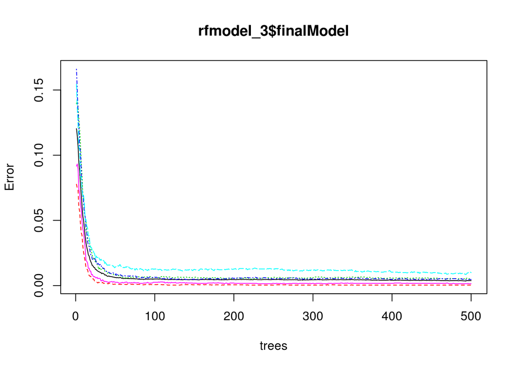

```r
plot(rfmodel_3$finalModel)
```

## Metrics

The accuracy and out-of-Bag errors are given below and this gets a 100 % correct on the course quiz with 20 test cases.

```r
rfmodel_3
```

```
## Random Forest
##
## 19622 samples
##    40 predictors
##     5 classes: 'A', 'B', 'C', 'D', 'E'
##
## Pre-processing: nearest neighbor imputation (40), centered (40),
##  scaled (40)
## Resampling: Cross-Validated (10 fold)
## Summary of sample sizes: 17659, 17661, 17658, 17659, 17660, 17661, ...
## Resampling results across tuning parameters:
##
##   mtry  Accuracy   Kappa
##    2    0.9960250  0.9949718
##   21    0.9957189  0.9945848
##   40    0.9908771  0.9884591
##
## Accuracy was used to select the optimal model using  the largest value.
## The final value used for the model was mtry = 2.
```

## Confusion Matrix

```r
rfmodel_3$finalModel
```

```
##
## Call:
##  randomForest(x = x, y = y, mtry = param$mtry)
##                Type of random forest: classification
##                      Number of trees: 500
## No. of variables tried at each split: 2
##
##         OOB estimate of  error rate: 0.38%
## Confusion matrix:
##      A    B    C    D    E  class.error
## A 5578    1    0    0    1 0.0003584229
## B   14 3777    6    0    0 0.0052673163
## C    0   15 3406    1    0 0.0046756283
## D    0    0   30 3184    2 0.0099502488
## E    0    0    1    4 3602 0.0013861935
```